# Session 6

1. Séries temporelles
2. Graphiques avec pandas
3. Graphiques avec matplotlib
4. Graphiques avec seaborn
5. Cartes : matplotlib, plotly et ipyleaflet

```python
# imports
import numpy as np
import pandas as pd
import matplotlib.pyplot as plt
```

## 1. Séries temporelles

Le module datetime :

- **date**: date (year, month, day) calendrier Grégorien
- **time**: temps (hours, minutes, seconds, microseconds)
- **datetime**: timestamp (date + time)
- **timedelta**: durée, différence entre 2 dates ou 2 temps (days, hours, minutes, seconds, microseconds)
- **tzinfo**: gestion des fuseaux horaires (time zones)

Voir : https://docs.python.org/fr/3.7/library/datetime.html

```python
# import
import datetime
```

### 1.1 Objets temporels

```python
# date
today = datetime.date.today()
today
```

```
datetime.date(2021, 10, 20)
```

```python
# datetime
now = datetime.datetime.now()
now
```

```
datetime.datetime(2021, 10, 20, 13, 39, 27, 418649)
```

```python
# UTC datetime
now_utc = datetime.datetime.utcnow()
now_utc
```

```
datetime.datetime(2021, 10, 20, 11, 39, 38, 238268)
```

```python
# timedelta
today - datetime.date(2021, 1, 1)
```

```
datetime.timedelta(days=292)
```

```python
# addition entre une date et un timedelta
now + datetime.timedelta(days=100)
```

```
datetime.datetime(2022, 1, 28, 13, 39, 27, 418649)
```

```python
# différence entre une date et un timedelta
now - datetime.timedelta(days=100)
```

```
datetime.datetime(2021, 7, 12, 13, 39, 27, 418649)
```

```python
# import pytz
from pytz import timezone
```

```python
# build a timezone object
tz = timezone('Asia/Shanghai')
tz
```

```
<DstTzInfo 'Asia/Shanghai' LMT+8:06:00 STD>
```

```python
# convertion d'un datetime selon un fuseau horaire
now.astimezone(tz)
```

```
datetime.datetime(2021, 10, 20, 19, 39, 27, 418649, tzinfo=<DstTzInfo 'Asia/Shanghai' CST+8:00:00 STD>)
```

### 1.2 Ecriture et lecture

- strftime() : écrire un datetime selon un format donné
- strptime() : lire un datetime selon un format donné

| Directives | Comments |
| --- | --- |
| %a | Day of the week abbreviated |
| %A | Day of the week |
| %w | Day of the week 0 = Sunday ... 6 = Saturday |
| %d | Day of month on 2 digits 01, 02, ..., 31 |
| %j | Day of year on 3 digits 001, 002, ..., 366 |
| %b | Month abbreviated |
| %B | Month name |
| %m | Month on 2 digits 01, 02, ..., 12 |
| %U | Number of week in year (Sunday = first day) |
| %W | Number of week in year (Monday = first day) |
| %y | Year without the century on 2 digits 00, 01, ..., 99 |
| %Y | Year with the century on 4 digits 0001, 0002, ..., 2018, 2019, ..., 9998, 9999 |
| %H | Hour over 24 00, 01, ..., 23 |
| %I | Hour over 12 01, 02, ..., 12 |
| %p | AM or PM |
| %M | Minute on 2 digits 00, 01, ..., 59 |
| %S | Second on 2 digits 00, 01, ..., 59 |
| %f | Microsecond on 6 digits 000000, 000001, ..., 999999 |
| %z | UTC offset +HHMM or -HHMM |
| %Z | Time zone |
| %c | Representation date and temps |
| %x | Representation date |
| %X | Representation time |
| %% | Character % |

```python
# datetime
now = datetime.datetime.now()
now
```

```
datetime.datetime(2021, 10, 20, 13, 42, 21, 296594)
```

```python
# jour dela semaine
now.strftime("%A %d/%m/%Y")
```

```
'Wednesday 20/10/2021'
```

```python
# locale
# mettre parfois fr_FR ou fr_FR.UTF-8 au lien de fr, etc.
import locale
#locale.setlocale(locale.LC_ALL, 'ar') # arabic
#locale.setlocale(locale.LC_ALL, 'de') # german
#locale.setlocale(locale.LC_ALL, 'es') # spanish
#locale.setlocale(locale.LC_ALL, 'en') # english
#locale.setlocale(locale.LC_ALL, 'fa') # iranian
locale.setlocale(locale.LC_ALL, 'fr') # french
#locale.setlocale(locale.LC_ALL, 'hi') # hindi
#locale.setlocale(locale.LC_ALL, 'he') # hebrew
#locale.setlocale(locale.LC_ALL, 'it') # italian
#locale.setlocale(locale.LC_ALL, 'ja') # japanese
#locale.setlocale(locale.LC_ALL, 'lt') # lithuanian
#locale.setlocale(locale.LC_ALL, 'ko') # korean
#locale.setlocale(locale.LC_ALL, 'ro') # romanian
#locale.setlocale(locale.LC_ALL, 'ru') # russian
#locale.setlocale(locale.LC_ALL, 'sr') # serbian
#locale.setlocale(locale.LC_ALL, 'tr') # turkish
#locale.setlocale(locale.LC_ALL, 'zh') # chinese
now.strftime("%A %B %d/%m/%Y")
```

```
'mercredi octobre 20/10/2021'
```

```python
# lecture au format : AA-MM-DD-HH-MM
# écriture au format : HH:MM DD/MM/YYYY
var = datetime.datetime.strptime("20-11-04-10-30", "%y-%m-%d-%H-%M")
var.strftime("%H:%M %d/%m/%Y")
```

```
'10:30 04/11/2020'
```

**Exercice n° 1**

- Prendre le DataFrame des villes 'cities500.txt', combien a-t-on de fuseaux horaires ?
- Remplacez les valeurs de la colonne "timezone" par des objets "timezone".
- Prenez le datetime courant (now), convertissez-le avec toutes les valeurs de la colonne "timezone", et produisez des chaines de caractères au format format: `'%Y-%m-%d %H:%M:%S'`
- Il y a 24 heures dans une journée, combien obtient-on de fuseaux horaires différents ?

```python
df = pd.read_csv('cities500.zip',
                 sep='\t',
                 header=None,
                 keep_default_na=False,  # NA = North America
                 na_values=['', -9999],
                 names=['geonameid', 'name', 'asciiname', 'alternatenames', 'latitude',
                        'longitude', 'feature class', 'feature code', 'country code',
                        'cc2', 'admin1 code', 'admin2 code', 'admin3 code', 'admin4 code',
                        'population', 'elevation', 'dem', 'timezone', 'modification date'],
                dtype={'admin1 code': str,
                       'admin2 code': str,
                       'admin3 code': str,
                       'admin4 code': str})
df.head()
```

|  | geonameid | name | asciiname | alternatenames | latitude | longitude | feature class | feature code | country code | cc2 | admin1 code | admin2 code | admin3 code | admin4 code | population | elevation | dem | timezone | modification date |
| --- | --- | --- | --- | --- | --- | --- | --- | --- | --- | --- | --- | --- | --- | --- | --- | --- | --- | --- | --- |
| 0 | 3038999 | Soldeu | Soldeu | NaN | 42.57688 | 1.66769 | P | PPL | AD | NaN | 02 | NaN | NaN | NaN | 602 | NaN | 1832.0 | Europe/Andorra | 2017-11-06 |
| 1 | 3039154 | El Tarter | El Tarter | Ehl Tarter,Эл Тартер | 42.57952 | 1.65362 | P | PPL | AD | NaN | 02 | NaN | NaN | NaN | 1052 | NaN | 1721.0 | Europe/Andorra | 2012-11-03 |
| 2 | 3039163 | Sant Julià de Lòria | Sant Julia de Loria | San Julia,San Julià,Sant Julia de Loria,Sant J... | 42.46372 | 1.49129 | P | PPLA | AD | NaN | 06 | NaN | NaN | NaN | 8022 | NaN | 921.0 | Europe/Andorra | 2013-11-23 |
| 3 | 3039604 | Pas de la Casa | Pas de la Casa | Pas de la Kasa,Пас де ла Каса | 42.54277 | 1.73361 | P | PPL | AD | NaN | 03 | NaN | NaN | NaN | 2363 | 2050.0 | 2106.0 | Europe/Andorra | 2008-06-09 |
| 4 | 3039678 | Ordino | Ordino | Ordino,ao er di nuo,orudino jiao qu,Ордино,オルデ... | 42.55623 | 1.53319 | P | PPLA | AD | NaN | 05 | NaN | NaN | NaN | 3066 | NaN | 1296.0 | Europe/Andorra | 2018-10-26 |

```python
now
```

```
datetime.datetime(2021, 10, 20, 13, 42, 21, 296594)
```

```python
df['timezone'].apply(timezone).apply(lambda x: now.astimezone(x)).\
    apply(lambda x: x.strftime('%Y-%m-%d %H:%M:%S')).nunique()
```

```
36
```

### 1.3 Séries temporelles

```python
def df_taux_change(devises):
    df = pd.read_csv("Webstat_Export_20210929.csv",
                     sep=";",
                     na_values='-',
                     decimal=',',
                     skiprows=[0, 1, 3, 4, 5],  # le skiprows permet à l'option "decimal" de fonctionner
                     converters={0: lambda x: pd.to_datetime(x, format='%d/%m/%Y', errors='ignore')})

    # extraction des codes monnaies
    cols = pd.Series(df.columns.tolist()).str.extract('\(([A-Z]{3})\)', expand=True)
    cols.iloc[0] = 'Date'
    df.columns = cols[0]

    # selection des devises
    df = df[['Date'] + devises]

    # drop na
    df = df.dropna()

    # set index
    df = df.set_index('Date')

    return df
```

```python
df = df_taux_change(['USD', 'CHF', 'GBP', 'JPY', 'RUB', 'CNY'])
df.head()
```

| Date | USD | CHF | GBP | JPY | RUB | CNY |
| --- | --- | --- | --- | --- | --- | --- |
| 2021-09-28 | 1.1678 | 1.0840 | 0.85950 | 130.17 | 84.7497 | 7.5433 |
| 2021-09-27 | 1.1698 | 1.0850 | 0.85420 | 129.74 | 84.9955 | 7.5609 |
| 2021-09-24 | 1.1719 | 1.0830 | 0.85703 | 129.49 | 85.5104 | 7.5803 |
| 2021-09-23 | 1.1715 | 1.0831 | 0.85495 | 128.88 | 85.2372 | 7.5643 |
| 2021-09-22 | 1.1729 | 1.0820 | 0.86000 | 128.50 | 85.3877 | 7.5850 |

```python
df.info()
```

```
<class 'pandas.core.frame.DataFrame'>
DatetimeIndex: 5555 entries, 2021-09-28 to 2000-01-13
Data columns (total 6 columns):
 #   Column  Non-Null Count  Dtype
---  ------  --------------  -----
 0   USD     5555 non-null   float64
 1   CHF     5555 non-null   float64
 2   GBP     5555 non-null   float64
 3   JPY     5555 non-null   float64
 4   RUB     5555 non-null   float64
 5   CNY     5555 non-null   float64
dtypes: float64(6)
memory usage: 303.8 KB
```

**L'accesseur dt**

```python
# reset_index
df = df.reset_index()
df.head()
```

|  | Date | USD | CHF | GBP | JPY | RUB | CNY |
| --- | --- | --- | --- | --- | --- | --- | --- |
| 0 | 2021-09-28 | 1.1678 | 1.0840 | 0.85950 | 130.17 | 84.7497 | 7.5433 |
| 1 | 2021-09-27 | 1.1698 | 1.0850 | 0.85420 | 129.74 | 84.9955 | 7.5609 |
| 2 | 2021-09-24 | 1.1719 | 1.0830 | 0.85703 | 129.49 | 85.5104 | 7.5803 |
| 3 | 2021-09-23 | 1.1715 | 1.0831 | 0.85495 | 128.88 | 85.2372 | 7.5643 |
| 4 | 2021-09-22 | 1.1729 | 1.0820 | 0.86000 | 128.50 | 85.3877 | 7.5850 |

```python
df.info()
```

```
<class 'pandas.core.frame.DataFrame'>
RangeIndex: 5555 entries, 0 to 5554
Data columns (total 7 columns):
 #   Column  Non-Null Count  Dtype
---  ------  --------------  -----
 0   Date    5555 non-null   datetime64[ns]
 1   USD     5555 non-null   float64
 2   CHF     5555 non-null   float64
 3   GBP     5555 non-null   float64
 4   JPY     5555 non-null   float64
 5   RUB     5555 non-null   float64
 6   CNY     5555 non-null   float64
dtypes: datetime64[ns](1), float64(6)
memory usage: 303.9 KB
```

```python
# access to year
df['Date'].dt.year
```

```
0       2021
1       2021
2       2021
3       2021
4       2021
        ...
5550    2000
5551    2000
5552    2000
5553    2000
5554    2000
Name: Date, Length: 5555, dtype: int64
```

```python
# access to month
df['Date'].dt.month
```

```
0       9
1       9
2       9
3       9
4       9
       ..
5550    1
5551    1
5552    1
5553    1
5554    1
Name: Date, Length: 5555, dtype: int64
```

```python
# access to week days
df['Date'].dt.weekday
```

```
0       1
1       0
2       4
3       3
4       2
       ..
5550    2
5551    1
5552    0
5553    4
5554    3
Name: Date, Length: 5555, dtype: int64
```

**Sélection de données temporelles**

```python
# setting the index as a datetime object
df = df.set_index('Date')
df = df.sort_index()
df
```

| Date | USD | CHF | GBP | JPY | RUB | CNY |
| --- | --- | --- | --- | --- | --- | --- |
| 2000-01-13 | 1.0276 | 1.6111 | 0.62550 | 108.89 | 29.4837 | 8.5054 |
| 2000-01-14 | 1.0225 | 1.6130 | 0.62210 | 108.05 | 29.2350 | 8.4632 |
| 2000-01-17 | 1.0094 | 1.6136 | 0.61800 | 105.81 | 28.9738 | 8.3548 |
| 2000-01-18 | 1.0093 | 1.6131 | 0.61740 | 106.42 | 28.8510 | 8.3540 |
| 2000-01-19 | 1.0105 | 1.6120 | 0.61720 | 106.99 | 28.8815 | 8.3639 |
| ... | ... | ... | ... | ... | ... | ... |
| 2021-09-22 | 1.1729 | 1.0820 | 0.86000 | 128.50 | 85.3877 | 7.5850 |
| 2021-09-23 | 1.1715 | 1.0831 | 0.85495 | 128.88 | 85.2372 | 7.5643 |
| 2021-09-24 | 1.1719 | 1.0830 | 0.85703 | 129.49 | 85.5104 | 7.5803 |
| 2021-09-27 | 1.1698 | 1.0850 | 0.85420 | 129.74 | 84.9955 | 7.5609 |
| 2021-09-28 | 1.1678 | 1.0840 | 0.85950 | 130.17 | 84.7497 | 7.5433 |

5555 rows × 6 columns

```python
# yearly data
df.loc['2021']
```

| Date | USD | CHF | GBP | JPY | RUB | CNY |
| --- | --- | --- | --- | --- | --- | --- |
| 2021-01-04 | 1.2296 | 1.0811 | 0.90160 | 126.62 | 90.3420 | 7.9484 |
| 2021-01-05 | 1.2271 | 1.0803 | 0.90333 | 126.25 | 91.6715 | 7.9315 |
| 2021-01-06 | 1.2338 | 1.0821 | 0.90635 | 127.03 | 90.8175 | 7.9653 |
| 2021-01-07 | 1.2276 | 1.0833 | 0.90190 | 127.13 | 91.2000 | 7.9392 |
| 2021-01-08 | 1.2250 | 1.0827 | 0.90128 | 127.26 | 90.8000 | 7.9184 |
| ... | ... | ... | ... | ... | ... | ... |
| 2021-09-22 | 1.1729 | 1.0820 | 0.86000 | 128.50 | 85.3877 | 7.5850 |
| 2021-09-23 | 1.1715 | 1.0831 | 0.85495 | 128.88 | 85.2372 | 7.5643 |
| 2021-09-24 | 1.1719 | 1.0830 | 0.85703 | 129.49 | 85.5104 | 7.5803 |
| 2021-09-27 | 1.1698 | 1.0850 | 0.85420 | 129.74 | 84.9955 | 7.5609 |
| 2021-09-28 | 1.1678 | 1.0840 | 0.85950 | 130.17 | 84.7497 | 7.5433 |

190 rows × 6 columns

```python
# monthly data
df.loc['2020/01'] # or df.loc['01/2020']
```

| Date | USD | CHF | GBP | JPY | RUB | CNY |
| --- | --- | --- | --- | --- | --- | --- |
| 2020-01-02 | 1.1193 | 1.0865 | 0.84828 | 121.75 | 69.1893 | 7.7946 |
| 2020-01-03 | 1.1147 | 1.0840 | 0.85115 | 120.54 | 69.1190 | 7.7712 |
| 2020-01-06 | 1.1194 | 1.0850 | 0.85215 | 121.02 | 69.4047 | 7.8049 |
| 2020-01-07 | 1.1172 | 1.0850 | 0.85183 | 121.15 | 69.2576 | 7.7562 |
| 2020-01-08 | 1.1115 | 1.0792 | 0.84868 | 120.86 | 68.6389 | 7.7184 |
| 2020-01-09 | 1.1110 | 1.0808 | 0.85285 | 121.54 | 68.0757 | 7.7011 |
| 2020-01-10 | 1.1091 | 1.0822 | 0.84810 | 121.60 | 68.0410 | 7.6773 |
| 2020-01-13 | 1.1126 | 1.0811 | 0.85760 | 122.25 | 68.0893 | 7.6697 |
| 2020-01-14 | 1.1115 | 1.0767 | 0.85618 | 122.32 | 68.2418 | 7.6536 |
| 2020-01-15 | 1.1142 | 1.0751 | 0.85683 | 122.43 | 68.4386 | 7.6746 |
| 2020-01-16 | 1.1169 | 1.0739 | 0.85470 | 122.80 | 68.8102 | 7.6837 |
| 2020-01-17 | 1.1108 | 1.0736 | 0.85105 | 122.31 | 68.2495 | 7.6186 |
| 2020-01-20 | 1.1085 | 1.0737 | 0.85275 | 122.14 | 68.2075 | 7.6112 |
| 2020-01-21 | 1.1115 | 1.0743 | 0.85030 | 122.31 | 68.7300 | 7.6732 |
| 2020-01-22 | 1.1088 | 1.0757 | 0.84445 | 121.93 | 68.6934 | 7.6530 |
| 2020-01-23 | 1.1091 | 1.0734 | 0.84498 | 121.50 | 68.6301 | 7.6897 |
| 2020-01-24 | 1.1035 | 1.0712 | 0.84313 | 120.96 | 68.1692 | 7.6509 |
| 2020-01-27 | 1.1025 | 1.0689 | 0.84358 | 120.11 | 69.0442 | 7.6477 |
| 2020-01-28 | 1.1005 | 1.0703 | 0.84603 | 120.02 | 68.9032 | 7.6338 |
| 2020-01-29 | 1.1001 | 1.0729 | 0.84580 | 120.06 | 68.9755 | 7.6310 |
| 2020-01-30 | 1.1029 | 1.0690 | 0.84183 | 120.03 | 69.6719 | 7.6504 |
| 2020-01-31 | 1.1052 | 1.0694 | 0.84175 | 120.35 | 70.3375 | 7.6664 |

```python
# slice selection
df.loc['12/2019':'01/2020']
```

| Date | USD | CHF | GBP | JPY | RUB | CNY |
| --- | --- | --- | --- | --- | --- | --- |
| 2019-12-02 | 1.1023 | 1.0995 | 0.85218 | 120.75 | 70.9217 | 7.7625 |
| 2019-12-03 | 1.1071 | 1.0947 | 0.85200 | 120.39 | 71.0634 | 7.8140 |
| 2019-12-04 | 1.1081 | 1.0956 | 0.84610 | 120.45 | 70.7959 | 7.8149 |
| 2019-12-05 | 1.1094 | 1.0964 | 0.84470 | 120.69 | 70.7798 | 7.8125 |
| 2019-12-06 | 1.1094 | 1.0968 | 0.84453 | 120.44 | 70.7441 | 7.7993 |
| 2019-12-09 | 1.1075 | 1.0959 | 0.84195 | 120.15 | 70.5731 | 7.7960 |
| 2019-12-10 | 1.1077 | 1.0922 | 0.84073 | 120.27 | 70.4627 | 7.7968 |
| 2019-12-11 | 1.1075 | 1.0916 | 0.84245 | 120.44 | 70.3925 | 7.7960 |
| 2019-12-12 | 1.1137 | 1.0939 | 0.84560 | 120.95 | 70.0885 | 7.8374 |
| 2019-12-13 | 1.1174 | 1.0982 | 0.83508 | 122.43 | 69.9930 | 7.7900 |
| 2019-12-16 | 1.1146 | 1.0953 | 0.83415 | 121.97 | 69.8317 | 7.8025 |
| 2019-12-17 | 1.1162 | 1.0946 | 0.84748 | 122.31 | 69.8758 | 7.8090 |
| 2019-12-18 | 1.1115 | 1.0913 | 0.85055 | 121.81 | 69.5288 | 7.7783 |
| 2019-12-19 | 1.1117 | 1.0899 | 0.85073 | 121.73 | 69.4593 | 7.7931 |
| 2019-12-20 | 1.1097 | 1.0883 | 0.85133 | 121.31 | 68.9657 | 7.7764 |
| 2019-12-23 | 1.1075 | 1.0870 | 0.85708 | 121.18 | 69.0297 | 7.7652 |
| 2019-12-24 | 1.1080 | 1.0878 | 0.85533 | 121.19 | 68.7932 | 7.7643 |
| 2019-12-27 | 1.1153 | 1.0890 | 0.85130 | 122.23 | 69.2013 | 7.8025 |
| 2019-12-30 | 1.1189 | 1.0871 | 0.85208 | 122.19 | 69.2781 | 7.8175 |
| 2019-12-31 | 1.1234 | 1.0854 | 0.85080 | 121.94 | 69.9563 | 7.8205 |
| 2020-01-02 | 1.1193 | 1.0865 | 0.84828 | 121.75 | 69.1893 | 7.7946 |
| 2020-01-03 | 1.1147 | 1.0840 | 0.85115 | 120.54 | 69.1190 | 7.7712 |
| 2020-01-06 | 1.1194 | 1.0850 | 0.85215 | 121.02 | 69.4047 | 7.8049 |
| 2020-01-07 | 1.1172 | 1.0850 | 0.85183 | 121.15 | 69.2576 | 7.7562 |
| 2020-01-08 | 1.1115 | 1.0792 | 0.84868 | 120.86 | 68.6389 | 7.7184 |
| 2020-01-09 | 1.1110 | 1.0808 | 0.85285 | 121.54 | 68.0757 | 7.7011 |
| 2020-01-10 | 1.1091 | 1.0822 | 0.84810 | 121.60 | 68.0410 | 7.6773 |
| 2020-01-13 | 1.1126 | 1.0811 | 0.85760 | 122.25 | 68.0893 | 7.6697 |
| 2020-01-14 | 1.1115 | 1.0767 | 0.85618 | 122.32 | 68.2418 | 7.6536 |
| 2020-01-15 | 1.1142 | 1.0751 | 0.85683 | 122.43 | 68.4386 | 7.6746 |
| 2020-01-16 | 1.1169 | 1.0739 | 0.85470 | 122.80 | 68.8102 | 7.6837 |
| 2020-01-17 | 1.1108 | 1.0736 | 0.85105 | 122.31 | 68.2495 | 7.6186 |
| 2020-01-20 | 1.1085 | 1.0737 | 0.85275 | 122.14 | 68.2075 | 7.6112 |
| 2020-01-21 | 1.1115 | 1.0743 | 0.85030 | 122.31 | 68.7300 | 7.6732 |
| 2020-01-22 | 1.1088 | 1.0757 | 0.84445 | 121.93 | 68.6934 | 7.6530 |
| 2020-01-23 | 1.1091 | 1.0734 | 0.84498 | 121.50 | 68.6301 | 7.6897 |
| 2020-01-24 | 1.1035 | 1.0712 | 0.84313 | 120.96 | 68.1692 | 7.6509 |
| 2020-01-27 | 1.1025 | 1.0689 | 0.84358 | 120.11 | 69.0442 | 7.6477 |
| 2020-01-28 | 1.1005 | 1.0703 | 0.84603 | 120.02 | 68.9032 | 7.6338 |
| 2020-01-29 | 1.1001 | 1.0729 | 0.84580 | 120.06 | 68.9755 | 7.6310 |
| 2020-01-30 | 1.1029 | 1.0690 | 0.84183 | 120.03 | 69.6719 | 7.6504 |
| 2020-01-31 | 1.1052 | 1.0694 | 0.84175 | 120.35 | 70.3375 | 7.6664 |

### Réindexation temporelle

La fonction date_range() permet de construire un nouvel index sur la base de limites et d'une fréquence donnée.

```python
# nouvel index avec toutes les dates
newindex = pd.date_range(start=df.index[0], end=df.index[-1], freq='D')
newindex
```

```
DatetimeIndex(['2000-01-13', '2000-01-14', '2000-01-15', '2000-01-16',
               '2000-01-17', '2000-01-18', '2000-01-19', '2000-01-20',
               '2000-01-21', '2000-01-22',
               ...
               '2021-09-19', '2021-09-20', '2021-09-21', '2021-09-22',
               '2021-09-23', '2021-09-24', '2021-09-25', '2021-09-26',
               '2021-09-27', '2021-09-28'],
              dtype='datetime64[ns]', length=7930, freq='D')
```

La méthode reindex() va produire un nouveau DataFrame avec des valeurs manquantes si le nouvel index comprend des valeurs nouvelles.

```python
# réindexation temporelle
var = df.reindex(newindex)
var.head()
```

|  | USD | CHF | GBP | JPY | RUB | CNY |
| --- | --- | --- | --- | --- | --- | --- |
| 2000-01-13 | 1.0276 | 1.6111 | 0.6255 | 108.89 | 29.4837 | 8.5054 |
| 2000-01-14 | 1.0225 | 1.6130 | 0.6221 | 108.05 | 29.2350 | 8.4632 |
| 2000-01-15 | NaN | NaN | NaN | NaN | NaN | NaN |
| 2000-01-16 | NaN | NaN | NaN | NaN | NaN | NaN |
| 2000-01-17 | 1.0094 | 1.6136 | 0.6180 | 105.81 | 28.9738 | 8.3548 |

Différentes méthodes permettent de combler les valeurs manquantes.

```python
# fillna forward
var.fillna(method='ffill').head()
```

|  | USD | CHF | GBP | JPY | RUB | CNY |
| --- | --- | --- | --- | --- | --- | --- |
| 2000-01-13 | 1.0276 | 1.6111 | 0.6255 | 108.89 | 29.4837 | 8.5054 |
| 2000-01-14 | 1.0225 | 1.6130 | 0.6221 | 108.05 | 29.2350 | 8.4632 |
| 2000-01-15 | 1.0225 | 1.6130 | 0.6221 | 108.05 | 29.2350 | 8.4632 |
| 2000-01-16 | 1.0225 | 1.6130 | 0.6221 | 108.05 | 29.2350 | 8.4632 |
| 2000-01-17 | 1.0094 | 1.6136 | 0.6180 | 105.81 | 28.9738 | 8.3548 |

```python
# fillna backward
var.fillna(method='bfill').head()
```

|  | USD | CHF | GBP | JPY | RUB | CNY |
| --- | --- | --- | --- | --- | --- | --- |
| 2000-01-13 | 1.0276 | 1.6111 | 0.6255 | 108.89 | 29.4837 | 8.5054 |
| 2000-01-14 | 1.0225 | 1.6130 | 0.6221 | 108.05 | 29.2350 | 8.4632 |
| 2000-01-15 | 1.0094 | 1.6136 | 0.6180 | 105.81 | 28.9738 | 8.3548 |
| 2000-01-16 | 1.0094 | 1.6136 | 0.6180 | 105.81 | 28.9738 | 8.3548 |
| 2000-01-17 | 1.0094 | 1.6136 | 0.6180 | 105.81 | 28.9738 | 8.3548 |

La méthode interpolate() remplace les valeurs manquantes par une interpolation linéraire.

```python
# interpolate
var.interpolate().head()
```

|  | USD | CHF | GBP | JPY | RUB | CNY |
| --- | --- | --- | --- | --- | --- | --- |
| 2000-01-13 | 1.027600 | 1.6111 | 0.625500 | 108.890000 | 29.483700 | 8.505400 |
| 2000-01-14 | 1.022500 | 1.6130 | 0.622100 | 108.050000 | 29.235000 | 8.463200 |
| 2000-01-15 | 1.018133 | 1.6132 | 0.620733 | 107.303333 | 29.147933 | 8.427067 |
| 2000-01-16 | 1.013767 | 1.6134 | 0.619367 | 106.556667 | 29.060867 | 8.390933 |
| 2000-01-17 | 1.009400 | 1.6136 | 0.618000 | 105.810000 | 28.973800 | 8.354800 |

```python
# numpy linspace
np.linspace(0, 100, 21)
```

```
array([  0.,   5.,  10.,  15.,  20.,  25.,  30.,  35.,  40.,  45.,  50.,
        55.,  60.,  65.,  70.,  75.,  80.,  85.,  90.,  95., 100.])
```

```python
# interpolate linear = numpy.linspace (lignes 1 et 4 pour ligne 2 et 3)
array = np.linspace(var.iloc[1], var.iloc[4], 4)
pd.DataFrame(array)
```

|  | 0 | 1 | 2 | 3 | 4 | 5 |
| --- | --- | --- | --- | --- | --- | --- |
| 0 | 1.022500 | 1.6130 | 0.622100 | 108.050000 | 29.235000 | 8.463200 |
| 1 | 1.018133 | 1.6132 | 0.620733 | 107.303333 | 29.147933 | 8.427067 |
| 2 | 1.013767 | 1.6134 | 0.619367 | 106.556667 | 29.060867 | 8.390933 |
| 3 | 1.009400 | 1.6136 | 0.618000 | 105.810000 | 28.973800 | 8.354800 |

**Agrégations temporelles**

Méthode resample qui se comporte comme un groupby.

```python
# yearly aggregation
df.resample('A').size()
```

```
Date
2000-12-31    247
2001-12-31    254
2002-12-31    255
2003-12-31    255
2004-12-31    259
2005-12-31    257
2006-12-31    255
2007-12-31    255
2008-12-31    256
2009-12-31    256
2010-12-31    258
2011-12-31    257
2012-12-31    256
2013-12-31    255
2014-12-31    255
2015-12-31    256
2016-12-31    257
2017-12-31    255
2018-12-31    255
2019-12-31    255
2020-12-31    257
2021-12-31    190
Freq: A-DEC, dtype: int64
```

```python
pd.DataFrame.resample?
```

```python
# yearly aggregation
df.resample('A').max()
```

| Date | USD | CHF | GBP | JPY | RUB | CNY |
| --- | --- | --- | --- | --- | --- | --- |
| 2000-12-31 | 1.0276 | 1.6147 | 0.64020 | 111.88 | 29.4837 | 8.5054 |
| 2001-12-31 | 0.9545 | 1.5434 | 0.64080 | 115.90 | 27.5286 | 7.9004 |
| 2002-12-31 | 1.0487 | 1.4856 | 0.65050 | 125.18 | 33.5108 | 8.6801 |
| 2003-12-31 | 1.2630 | 1.5729 | 0.72350 | 140.31 | 36.9555 | 10.4539 |
| 2004-12-31 | 1.3633 | 1.5838 | 0.70880 | 141.03 | 37.9096 | 11.2840 |
| 2005-12-31 | 1.3507 | 1.5635 | 0.70725 | 143.47 | 37.4442 | 11.1797 |
| 2006-12-31 | 1.3331 | 1.6069 | 0.70060 | 156.93 | 34.8930 | 10.4272 |
| 2007-12-31 | 1.4874 | 1.6803 | 0.73480 | 168.68 | 36.1180 | 10.9950 |
| 2008-12-31 | 1.5990 | 1.6529 | 0.97855 | 169.75 | 41.6925 | 11.1699 |
| 2009-12-31 | 1.5120 | 1.5421 | 0.96100 | 138.09 | 46.7135 | 10.3224 |
| 2010-12-31 | 1.4563 | 1.4873 | 0.91140 | 134.23 | 43.4300 | 9.9419 |
| 2011-12-31 | 1.4882 | 1.3163 | 0.90500 | 122.80 | 43.7214 | 9.6636 |
| 2012-12-31 | 1.3454 | 1.2196 | 0.84815 | 113.87 | 41.8100 | 8.4766 |
| 2013-12-31 | 1.3814 | 1.2599 | 0.87890 | 145.02 | 45.3246 | 8.4965 |
| 2014-12-31 | 1.3953 | 1.2383 | 0.83830 | 149.03 | 91.5200 | 8.6891 |
| 2015-12-31 | 1.2043 | 1.2022 | 0.78420 | 145.21 | 81.4420 | 7.4759 |
| 2016-12-31 | 1.1569 | 1.1169 | 0.90485 | 132.25 | 91.7660 | 7.5341 |
| 2017-12-31 | 1.2060 | 1.1772 | 0.92965 | 135.01 | 71.8059 | 7.9757 |
| 2018-12-31 | 1.2493 | 1.1986 | 0.90680 | 137.22 | 81.2688 | 8.0958 |
| 2019-12-31 | 1.1535 | 1.1470 | 0.92830 | 127.35 | 79.3589 | 7.9519 |
| 2020-12-31 | 1.2281 | 1.0866 | 0.92985 | 127.23 | 93.7450 | 8.2637 |
| 2021-12-31 | 1.2338 | 1.1114 | 0.90635 | 134.05 | 92.3842 | 7.9653 |

```python
# monthly aggregation
df.resample('MS').mean()
```

| Date | USD | CHF | GBP | JPY | RUB | CNY |
| --- | --- | --- | --- | --- | --- | --- |
| 2000-01-01 | 1.004985 | 1.612115 | 0.612831 | 106.091538 | 28.742685 | 8.318246 |
| 2000-02-01 | 0.983424 | 1.606886 | 0.614657 | 107.640952 | 28.288986 | 8.139800 |
| 2000-03-01 | 0.964343 | 1.604243 | 0.610626 | 102.590870 | 27.466526 | 7.981870 |
| 2000-04-01 | 0.946950 | 1.573956 | 0.598017 | 99.924444 | 27.098239 | 7.837911 |
| 2000-05-01 | 0.905968 | 1.556164 | 0.601509 | 98.090455 | 25.657673 | 7.498705 |
| ... | ... | ... | ... | ... | ... | ... |
| 2021-05-01 | 1.214590 | 1.096829 | 0.862583 | 132.569048 | 89.873662 | 7.810919 |
| 2021-06-01 | 1.204709 | 1.094000 | 0.858720 | 132.631364 | 87.456068 | 7.739114 |
| 2021-07-01 | 1.182182 | 1.085595 | 0.856130 | 130.349091 | 87.397018 | 7.653632 |
| 2021-08-01 | 1.177182 | 1.076177 | 0.852874 | 129.284091 | 86.606650 | 7.623655 |
| 2021-09-01 | 1.178570 | 1.086010 | 0.856268 | 129.644000 | 85.900290 | 7.609820 |

261 rows × 6 columns

```python
# monthly aggregation
df.resample('MS').apply(lambda x: x.size)
```

| Date | USD | CHF | GBP | JPY | RUB | CNY |
| --- | --- | --- | --- | --- | --- | --- |
| 2000-01-01 | 13.0 | 13.0 | 13.0 | 13.0 | 13.0 | 13.0 |
| 2000-02-01 | 21.0 | 21.0 | 21.0 | 21.0 | 21.0 | 21.0 |
| 2000-03-01 | 23.0 | 23.0 | 23.0 | 23.0 | 23.0 | 23.0 |
| 2000-04-01 | 18.0 | 18.0 | 18.0 | 18.0 | 18.0 | 18.0 |
| 2000-05-01 | 22.0 | 22.0 | 22.0 | 22.0 | 22.0 | 22.0 |
| ... | ... | ... | ... | ... | ... | ... |
| 2021-05-01 | 21.0 | 21.0 | 21.0 | 21.0 | 21.0 | 21.0 |
| 2021-06-01 | 22.0 | 22.0 | 22.0 | 22.0 | 22.0 | 22.0 |
| 2021-07-01 | 22.0 | 22.0 | 22.0 | 22.0 | 22.0 | 22.0 |
| 2021-08-01 | 22.0 | 22.0 | 22.0 | 22.0 | 22.0 | 22.0 |
| 2021-09-01 | 20.0 | 20.0 | 20.0 | 20.0 | 20.0 | 20.0 |

261 rows × 6 columns

| Alias | Offset type | Description |
| --- | --- | --- |
| D | Day | Calendar daily |
| B | BusinessDay | Business daily |
| H | Hour | Hourly |
| T or min | Minute | Minutely |
| S | Second | Secondly |
| L or ms | Milli | Millisecond (1/1000th of 1 second) |
| U | Micro | Microsecond (1/1000000th of 1 second) |
| M | MonthEnd | Last calendar day of month |
| BM | BusinessMonthEnd | Last business day (weekday) of month |
| MS | MonthBegin | First calendar day of month |
| BMS | BusinessMonthBegin | First weekday of month |
| W-MON, W-TUE, ... | Week | Weekly on given day of week: MON, TUE, WED, THU, FRI, SAT, or SUN. |
| Q-JAN, Q-FEB, ... | QuarterEnd | Quarterly dates anchored on last calendar day of each month,for year ending in indicated month: JAN, FEB, MAR, APR, MAY, JUN, JUL, AUG, SEP, OCT, NOV, or DEC. |
| A-JAN, A-FEB, ... | YearEnd | Annual dates anchored on last calendar day of given month: JAN, FEB, MAR, APR, MAY, JUN, JUL, AUG, SEP, OCT, NOV, or DEC. |

Source: Python for Data Analysis, Wes McKinney, O'Reilly

**Graphiques temporels**

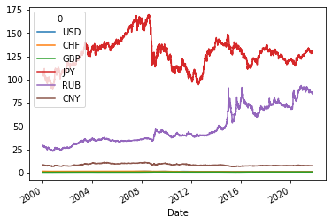

```python
# taux de change
df.plot();
```

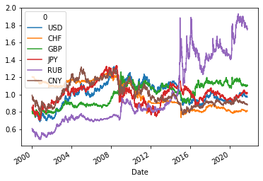

```python
# taux de change divisés par leur moyenne
(df / df.mean()).plot();
```

```python
df.mean()
```

```
0
USD      1.206063
CHF      1.339941
GBP      0.776449
JPY    127.429932
RUB     48.547608
CNY      8.577649
dtype: float64
```

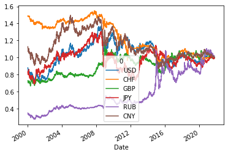

```python
# taux de change divisés par la dernière valeur
(df / df.iloc[-1]).plot();
```

```python
df.iloc[-1]
```

```
0
USD      1.1678
CHF      1.0840
GBP      0.8595
JPY    130.1700
RUB     84.7497
CNY      7.5433
Name: 2021-09-28 00:00:00, dtype: float64
```

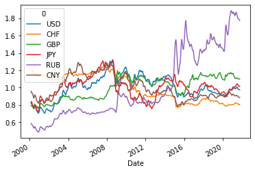

```python
# taux de change divisés par leur moyenne avec une moyenne glissante de 30 jours
(df / df.mean()).rolling(30).mean().plot()
plt.show()
```

**Exercice n° 2**

Affichez les taux de change divisés par la dernière valeur connue avec une moyenne glissante de 30 jours.

Affichez les taux de change divisés par leur moyenne avec un maximum glissant sur 100 jours.

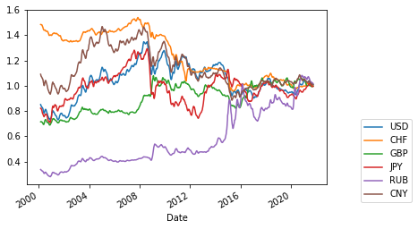

```python
(df / df.iloc[-1]).rolling(30).mean().plot()
plt.legend(bbox_to_anchor=(1.3, 0.4));
```

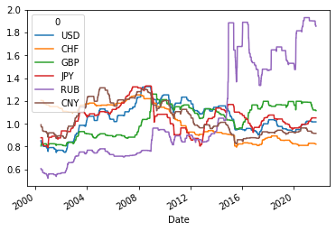

```python
(df / df.mean()).rolling(100).max().plot();
```

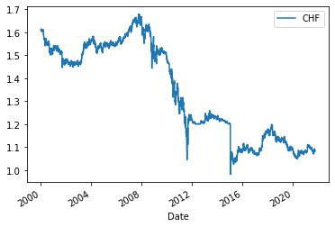

```python
df['CHF'].plot()
plt.legend();
```

## 2. Graphiques avec pandas

pandas propose une API relativement simple qui s'appuie sur matplotlib.

https://pandas.pydata.org/pandas-docs/stable/user_guide/visualization.html

#### Data Names US et FR

```python
# names US
def df_names_us():
    dfs = []
    for year in range(1880, 2020):
        csv = pd.read_csv(f'names/yob{year}.txt',
                          names=['name', 'gender', 'births'])
        csv['year'] = year
        dfs.append(csv)
    df = pd.concat(dfs, ignore_index=True)
    df = df[['year', 'name', 'gender', 'births']]
    return df

df_us = df_names_us()
df_us.shape
```

```
(1989592, 4)
```

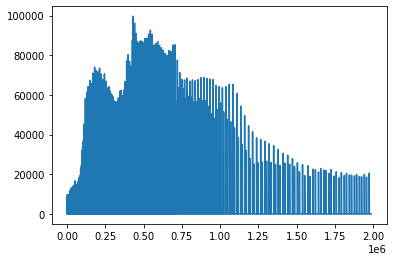

```python
df_us['births'].plot();
```

```python
def df_names_fr():
    # dict for gender
    d = {'1': 'M', '2': 'F'}
    # read table
    # no header
    # set columns
    # user converters for gender and name
    df = pd.read_csv('nat2020_csv.zip',
                      sep=';',
                      header=0,
                      names=['gender', 'name', 'year', 'births'],
                      converters={
                          'gender': d.get,
                          'name': str.title
                      })
    # select usable data
    # name with length > 1
    # year != 'XXXX'
    # name != '_Prenoms_Rares' (after use of str.title)
    df = df.loc[(df['name'].str.len() > 1)
                & (df['year'] != 'XXXX')
                & (df['name'] != '_Prenoms_Rares')]
    # set year type to int
    df['year'] = df['year'].astype(int)
    # set columns order
    df = df[['year', 'name', 'gender', 'births']]
    # sort data
    df = df.sort_values(['year', 'gender', 'births', 'name'],
                   ascending=[True, True, False, True])
    # reset index
    df = df.reset_index(drop=True)
    return df

df_fr = df_names_fr()
df_fr.shape
```

```
(630407, 4)
```

**Exercice n° 3**

Combinez les 2 DataFrames en un seul DataFrame avec une colonne en plus "country" valant "us" ou "fr".

```python
df_us['country'] = 'us'
df_fr['country'] = 'fr'
df = pd.concat([df_us, df_fr], ignore_index=True)
df
```

|  | year | name | gender | births | country |
| --- | --- | --- | --- | --- | --- |
| 0 | 1880 | Mary | F | 7065 | us |
| 1 | 1880 | Anna | F | 2604 | us |
| 2 | 1880 | Emma | F | 2003 | us |
| 3 | 1880 | Elizabeth | F | 1939 | us |
| 4 | 1880 | Minnie | F | 1746 | us |
| ... | ... | ... | ... | ... | ... |
| 2619994 | 2020 | Élouen | M | 3 | fr |
| 2619995 | 2020 | Énes | M | 3 | fr |
| 2619996 | 2020 | Éphraïm | M | 3 | fr |
| 2619997 | 2020 | Éros | M | 3 | fr |
| 2619998 | 2020 | Ézekiel | M | 3 | fr |

2619999 rows × 5 columns

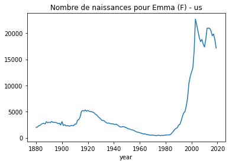

```python
# exemple
tab = df.loc[(df['country'] == 'us') & (df['name'] == 'Emma') & (df['gender'] == 'F')]
tab = tab.set_index('year')
tab['births'].plot(title='Nombre de naissances pour Emma (F) - us');
```

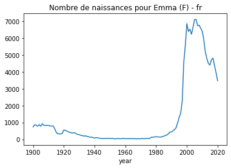

```python
# exemple
tab = df.loc[(df['country'] == 'fr') & (df['name'] == 'Emma') & (df['gender'] == 'F')]
tab = tab.set_index('year')
tab['births'].plot(title='Nombre de naissances pour Emma (F) - fr');
```

```python
# quelques fonctions
def select(country, name, gender):
    return df.loc[(df['country'] == country) &
                  (df['name'] == name) &
                  (df['gender'] == gender)]

def plot_names(country, name, gender):
    tab = select(country, name, gender)
    tab = tab.set_index('year')
    tab['births'].plot(title=f'Nombre de naissances pour {name} ({gender}) - {country}');
```

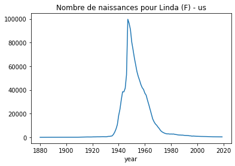

```python
plot_names('us', 'Linda', 'F')
```

**Exercice n° 4**

Afficher l'évolution du nombre de naissances US ou FR par année et par genre.

Afficher l'évolution de la diversité des prénoms US ou FR par année et par genre.

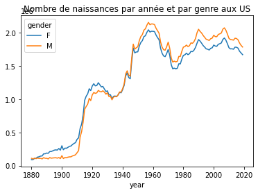

```python
tab = df_us.pivot_table(values='births',
                        index='year',
                        columns='gender',
                        aggfunc='sum')
tab.plot(title='Nombre de naissances par année et par genre aux US');
```

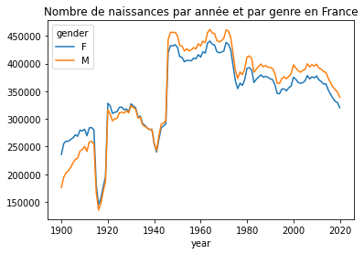

```python
tab = df_fr.pivot_table(values='births',
                        index='year',
                        columns='gender',
                        aggfunc='sum')
tab.plot(title='Nombre de naissances par année et par genre en France');
```

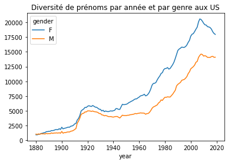

```python
tab = df_us.pivot_table(values='name',
                        index='year',
                        columns='gender',
                        aggfunc='count')
tab.plot(title='Diversité de prénoms par année et par genre aux US');
```

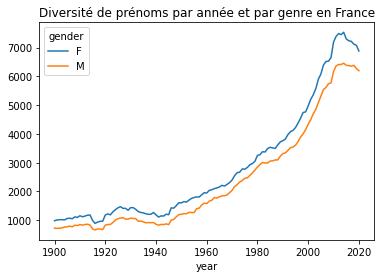

```python
tab = df_fr.pivot_table(values='name',
                        index='year',
                        columns='gender',
                        aggfunc='count')
tab.plot(title='Diversité de prénoms par année et par genre en France');
```

**bar plot**

```python
# sélection + pivot
top10 = ['Camille', 'Louise', 'Léa', 'Ambre', 'Agathe',
         'Louis', 'Gabriel', 'Léo', 'Maël', 'Paul']
selection = df.loc[(df['year'] == 2020) & (df['country'] == 'fr') & df['name'].isin(top10)]
tab = selection.pivot_table(values='births',
                      index='name',
                      aggfunc='sum')
tab
```

| name | births |
| --- | --- |
| Agathe | 1927 |
| Ambre | 2752 |
| Camille | 2569 |
| Gabriel | 4415 |
| Louis | 3795 |
| Louise | 3811 |
| Léa | 2429 |
| Léo | 4504 |
| Maël | 3301 |
| Paul | 2477 |

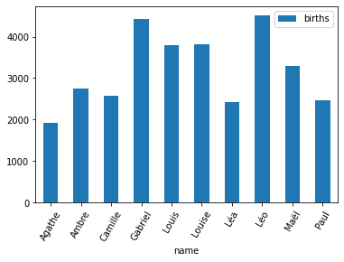

```python
# bar plot
tab.plot(kind='bar', rot=60);  # testez avec barh
```

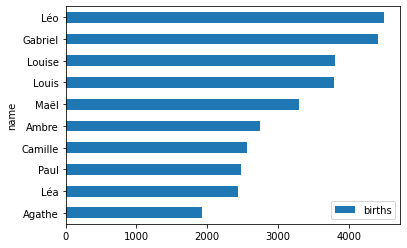

```python
# barh plot
tab.sort_values('births').plot(kind='barh');  # testez avec barh
```

#### pie plot

```python
# sélection + pivot
selection = df.loc[df['name']=='Jean']
tab = selection.pivot_table(values='births',
                            index='gender',
                            aggfunc='sum')
tab
```

| gender | births |
| --- | --- |
| F | 458485 |
| M | 1938216 |

```python
selection.groupby('gender')['births'].sum()
```

```
gender
F     458485
M    1938216
Name: births, dtype: int64
```

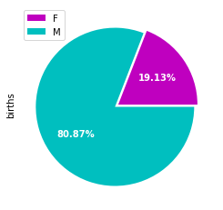

```python
# pie plot
tab.plot(kind='pie',
         y='births',
         colors=['m', 'c'],
         autopct='%1.2f%%',
         textprops={'color': 'w', 'weight': 'bold'},
         explode=(0.0, 0.05));
```

```python
pd.DataFrame.plot?
```

## 3. Graphiques avec matplotlib

- Objet principal : Figure
- Sous-graphiques : Axes à ne pas confondre avec les axes (axis en anglais)

Méthodes :

- add_subplot(ligne, colonne, n° de figure) ou 111, 121, 122... si < 10, par sous-graphique
- 221, 222, 223, 224
- subplots(nb lignes, nb colonnes) pour tous les sous-graphiques

On utilise la sous-librairie pyplot.

Voir : https://matplotlib.org/

#### Plusieurs courbes en un grahique

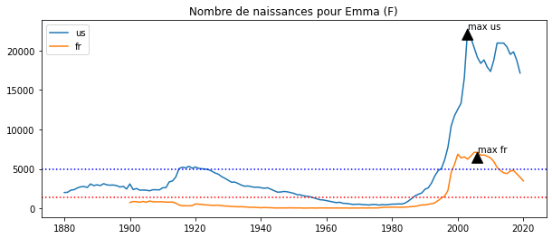

```python
# plusieurs courbes en un grahique
fig = plt.figure(figsize=(10, 4))
name, gender = 'Emma', 'F'

ax1 = fig.add_subplot(111)
ax1.set_title(f'Nombre de naissances pour {name} ({gender})')

country = 'us'
tab = select(country, name, gender)
tab = tab.set_index('year')
b = tab['births']
mean_us = b.mean()
ax1.plot(b);

xmax = tab['births'].idxmax()
ymax = tab['births'].max()
ax1.annotate('max us',
             xy=(xmax, ymax),
             xytext=(xmax, ymax+50),
             arrowprops=dict(facecolor='black', shrink=0.01))

country = 'fr'
tab = select(country, name, gender)
tab = tab.set_index('year')
b = tab['births']
mean_fr = b.mean()
ax1.plot(b);

ax1.axhline(y=mean_us, color='b', ls=':')
ax1.axhline(y=mean_fr, color='r', ls=':')

xmax = tab['births'].idxmax()
ymax = tab['births'].max()
ax1.annotate('max fr',
             xy=(xmax, ymax),
             xytext=(xmax, ymax+50),
             arrowprops=dict(facecolor='black', shrink=0.01))

ax1.legend(['us', 'fr']);
```

```python
plt.annotate?
```

#### Plusieurs grahiques avec add_subplot()

```python
# f-string
toto = 1
f'bla bla bla {toto:.2f}'
```

```
'bla bla bla 1.00'
```

```python
plt.figure?
```

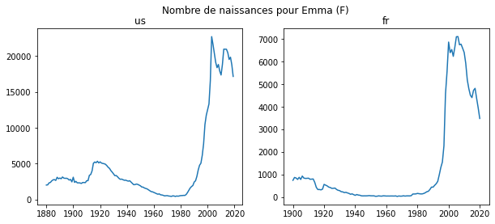

```python
def plot_country_name_gender(country, name, gender, ax):
    tab = select(country, name, gender)
    tab = tab.set_index('year')
    ax.set_title(country)
    ax.plot(tab['births']);

fig = plt.figure(figsize=(10, 4))
name, gender = 'Emma', 'F'

fig.suptitle(f'Nombre de naissances pour {name} ({gender})')

country = 'us'
ax1 = fig.add_subplot(121)
plot_country_name_gender(country, name, gender, ax1)

country = 'fr'
ax2 = fig.add_subplot(122)
plot_country_name_gender(country, name, gender, ax2)
```

#### Plusieurs grahiques avec subplots()

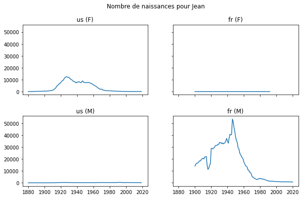

```python
def plot_country_name_gender(country, name, gender, ax):
    tab = select(country, name, gender)
    tab = tab.set_index('year')
    ax.set_title(f'{country} ({gender})')
    ax.plot(tab['births']);

name = 'Jean'
fig = plt.figure(figsize=(10, 6))
fig.suptitle(f'Nombre de naissances pour {name}')
# tableau lignes x colonnes
[[ax1, ax2], [ax3, ax4]] = fig.subplots(2, 2, sharex=True, sharey=True)
fig.subplots_adjust(hspace=0.3)  # séparation verticale

plot_country_name_gender('us', name, 'F', ax1)
plot_country_name_gender('fr', name, 'F', ax2)
plot_country_name_gender('us', name, 'M', ax3)
plot_country_name_gender('fr', name, 'M', ax4)
```

```python
#plt.Axes.plot?
```

> plot(x, y, color='green', marker='o', linestyle='dashed', ... linewidth=2, markersize=12)

Dans matplotlib il y a :

- 4 types de lignes: '-' (solid), '--' (dashed), ':' (dotted), '-.' (dashdotted)
- plusieurs referentiels de couleurs :
  - 8 couleurs basiques : 'b' (blue), 'c' (cyan), 'g' (green), 'k' (black), 'm' (magenta), 'r' (red), 'w' (white) and 'y' (yellow)
  - niveaux de gris : nombres sous forme de chaines entre '0.0' (noir) et '1.0' (blanc)
  - 148 couleurs nommées : voir la variable matplotlib.colors.cnames
  - 16+ millions de couleurs RVB en hexadecimal: #xxyyzz
- 41 marqueurs : see variable matplotlib.lines.Line2D.markers
- linewidth peut être remplacé par lw
- linestyle peut être remplacé par ls

```python
ax1.plot?
```

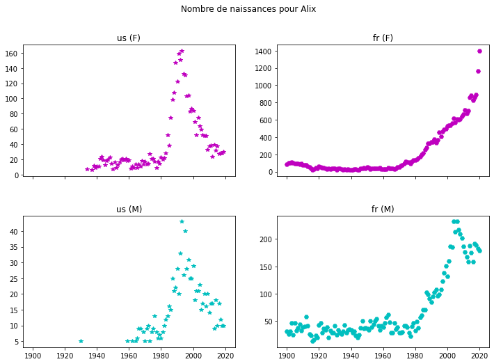

```python
def plot_country_name_gender(country, name, gender, ax):
    tab = select(country, name, gender)
    tab = tab.set_index('year')
    ax.set_title(f'{country} ({gender})')
    ax.plot(tab['births'],
            '*' if country=='us' else 'H',
            color='m' if gender=='F' else 'c');

name = 'Alix'
fig = plt.figure(figsize=(12, 8))
fig.suptitle(f'Nombre de naissances pour {name}')
# tableau lignes x colonnes
[[ax1, ax2], [ax3, ax4]] = fig.subplots(2, 2, sharex=True)
fig.subplots_adjust(hspace=0.3)  # séparation verticale

plot_country_name_gender('us', name, 'F', ax1)
plot_country_name_gender('fr', name, 'F', ax2)
plot_country_name_gender('us', name, 'M', ax3)
plot_country_name_gender('fr', name, 'M', ax4)
```

#### bar plot customisé

```python
# sélection + pivot
top10 = ['Camille', 'Louise', 'Léa', 'Ambre', 'Agathe',
         'Louis', 'Gabriel', 'Léo', 'Maël', 'Paul']
selection = df.loc[(df['year'] == 2020) & (df['country'] == 'fr') & df['name'].isin(top10)]
tab = selection.pivot_table(values='births',
                      index='name',
                      aggfunc='sum')
tab
```

| name | births |
| --- | --- |
| Agathe | 1927 |
| Ambre | 2752 |
| Camille | 2569 |
| Gabriel | 4415 |
| Louis | 3795 |
| Louise | 3811 |
| Léa | 2429 |
| Léo | 4504 |
| Maël | 3301 |
| Paul | 2477 |

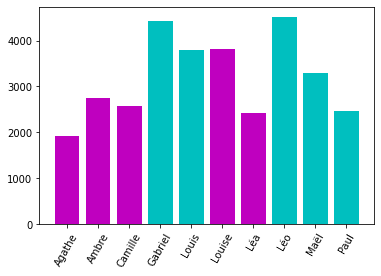

```python
# bar plot
plt.bar(x=tab.index, height=tab['births'], color=list('mmmccmmccc'));  # testez avec barh
plt.xticks(rotation=60);
```

Extension de matplotlib orientée statistiques.

Voir : https://seaborn.pydata.org/api.html

```python
# import
import seaborn as sns
```

#### countplot

Show the counts of observations in each categorical bin using bars.

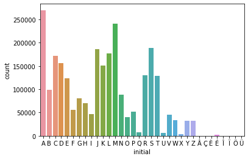

```python
# countplot
df['initial'] = df['name'].str[0]
df = df.sort_values('initial')
sns.countplot(data=df, x='initial');
```

#### barplot

Show point estimates and confidence intervals as rectangular bars.

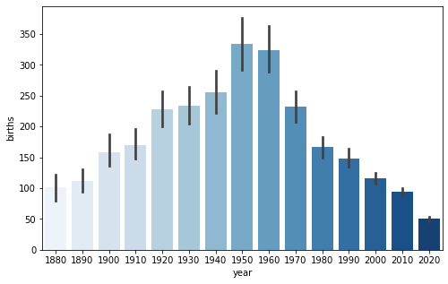

```python
# seaborn barplot with births for decades
plt.figure(figsize=(8, 5))
var = df.loc[df['year'] % 10 == 0]
sns.barplot(data=var, x='year', y='births', palette='Blues');
```

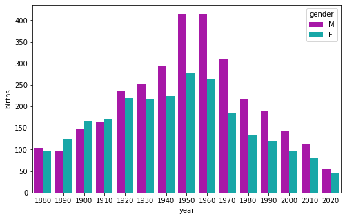

```python
# seaborn barplot with births for decades + hue
plt.figure(figsize=(8, 5))
var = df.loc[df['year'] % 10 == 0]
sns.barplot(data=var, x='year', y='births', hue='gender', palette=['m', 'c'], ci=None);
```

```python
df.groupby('year').mean().loc[1950]
```

```
births    334.328987
Name: 1950, dtype: float64
```

#### displot

Flexibly plot a univariate distribution of observations.

```python
# list of names which appear at least 10,000 times
var = df.pivot_table(index='name', values='births', aggfunc='sum')
var = var.loc[var['births'] >= 10_000]
names10000 = var.index

# data for names which appear at least 10,000 times
df10000 = df.loc[df['name'].isin(names10000)]
print(len(df10000))

# number of births by gender, and ratio F / (F + M)
var = df10000.pivot_table(index='name',
                          columns='gender',
                          values='births',
                          aggfunc='sum')
ratio = var['F'] / (var['F'] + var['M'])
ratio
```

```
568494
```

```
name
Aaliyah     0.998925
Aaron       0.007013
Abbey       0.997980
Abbie       0.985110
Abbigail    0.999576
              ...
Zion        0.165495
Zoe         0.996444
Zoey        0.997578
Zora        0.997914
Zoé         0.994942
Length: 3192, dtype: float64
```

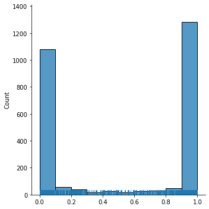

```python
# seaborn distplot
var = df.loc[df['year'] % 10 == 0]
sns.displot(ratio, kde=False, rug=True, bins=10);
```

#### regplot

Plot data and a linear regression model fit.

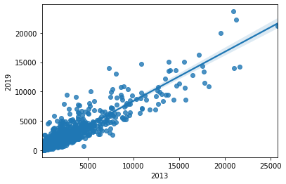

```python
# select years year1 and year2
year1 = 2013
year2 = 2019
var = df.loc[df["year"].isin([year1, year2])]
var = var.pivot_table(values="births",
                      index="name",
                      columns="year",
                      aggfunc='sum')
sns.regplot(x=var[year1], y=var[year2]);
```

```python
var.max()
```

[output not shown]

```python
from scipy.stats import linregress

var = var.dropna()
print(linregress(var[2013].values, var[2020].values))
```

[output not shown]

```python
slope, intercept, *args = linregress(var[2013].values, var[2020].values)
slope, intercept
```

```
(0.08738737455487566, 33.8569591512043)
```

```python
slope, intercept, _, _, _ = linregress(var[2013].values, var[2020].values)
slope, intercept
```

```
(0.08738737455487566, 33.8569591512043)
```

```python
_
```

```
0.0016011238560321
```